# Exploring Human Health Data with ggplot2 and dplyr

Tanishka Joshi

Last compiled on 2026-06-10

## Introduction

In this exercise you will work with a dataset of 200 human samples containing physical measurements and clinical lab values. You will practice:

- Reading tabular data into R
- Manipulating data with **dplyr** (`filter`, `select`, `mutate`, `group_by`, `summarize`)
- Visualizing data with **ggplot2**

The dataset (`human_health_data.tsv`) contains the following columns:

| Column | Description |
| --- | --- |
| `sample_id` | Unique sample identifier |
| `sex` | Biological sex (Male / Female) |
| `height_cm` | Height in centimetres |
| `weight_kg` | Weight in kilograms |
| `hair_color` | Hair color |
| `eye_color` | Eye color |
| `blood_glucose_mgdl` | Fasting blood glucose (mg/dL) |
| `LDL_mgdl` | LDL cholesterol (mg/dL) |

## Part 1 — Loading the data

**1.1** Load the `tidyverse` package and read `human_health_data.tsv` into a tibble called `health`. Use `read_tsv()`. Print the first few rows with `head()`.

```r
library(tidyverse)
library(readr)

health <- read_tsv("C:/Users/tanis/Gresham Lab/summerIntensive2026/data/human_health_data.tsv")
head(health)
```

| sample_id | sex | height_cm | weight_kg | hair_color | eye_color | blood_glucose_mgdl | LDL_mgdl |
| --- | --- | --- | --- | --- | --- | --- | --- |
| S001 | Male | 182.5 | 83.5 | Blonde | Hazel | 95.7 | 157.1 |
| S002 | Male | 175.5 | 80.4 | Brown | Blue | 100.5 | 127.6 |
| S003 | Female | 164.5 | 82.4 | Blonde | Blue | 97.3 | 117.4 |
| S004 | Female | 162.3 | 75.5 | Brown | Brown | 95.8 | 107.4 |
| S005 | Female | 154.3 | 55.9 | Gray | Brown | 89.3 | 85.1 |
| S006 | Female | 167.0 | 54.6 | Blonde | Brown | 98.2 | 88.5 |

```r
NA
```

**1.2** Use `glimpse()` to get an overview of the data types in `health`.

```r
glimpse(health)
```

```
Rows: 200
Columns: 8
$ sample_id          <chr> "S001", "S002", "S003", "S004", "S005", "S006", "S007", "S008", "S…
$ sex                <chr> "Male", "Male", "Female", "Female", "Female", "Female", "Male", "F…
$ height_cm          <dbl> 182.5, 175.5, 164.5, 162.3, 154.3, 167.0, 179.9, 165.9, 171.9, 171…
$ weight_kg          <dbl> 83.5, 80.4, 82.4, 75.5, 55.9, 54.6, 47.5, 76.8, 80.1, 60.8, 77.8, …
$ hair_color         <chr> "Blonde", "Brown", "Blonde", "Brown", "Gray", "Blonde", "Brown", "…
$ eye_color          <chr> "Hazel", "Blue", "Blue", "Brown", "Brown", "Brown", "Blue", "Brown…
$ blood_glucose_mgdl <dbl> 95.7, 100.5, 97.3, 95.8, 89.3, 98.2, 98.9, 85.7, 84.8, 90.3, 75.3,…
$ LDL_mgdl           <dbl> 157.1, 127.6, 117.4, 107.4, 85.1, 88.5, 71.0, 84.4, 122.7, 96.4, 1…
```

## Part 2 — Selecting and filtering (`select`, `filter`)

**2.1** Create a new tibble called `clinical` that contains only the columns `sample_id`, `sex`, `blood_glucose_mgdl`, and `LDL_mgdl`.

```r
clinical <- select(health, c("sample_id", "sex", "blood_glucose_mgdl", "LDL_mgdl"))
```

**2.2** From the original `health` tibble, filter to keep only **Female** samples whose `blood_glucose_mgdl` is greater than 100 mg/dL (pre-diabetic range). How many samples meet this criterion?

```r
filter(health, sex =="Female", blood_glucose_mgdl >100)
```

| sample_id | sex | height_cm | weight_kg | hair_color | eye_color | blood_glucose_mgdl | LDL_mgdl |
| --- | --- | --- | --- | --- | --- | --- | --- |
| S013 | Female | 149.6 | 96.9 | Blonde | Hazel | 116.1 | 150.1 |
| S015 | Female | 174.7 | 64.1 | Blonde | Blue | 108.3 | 117.3 |
| S023 | Female | 156.3 | 73.0 | Brown | Blue | 102.5 | 132.0 |
| S031 | Female | 165.9 | 64.2 | Red | Green | 103.0 | 116.1 |
| S032 | Female | 149.7 | 80.8 | Blonde | Brown | 116.5 | 122.5 |
| S034 | Female | 151.3 | 67.6 | Black | Brown | 112.8 | 172.7 |
| S044 | Female | 160.3 | 66.0 | Black | Brown | 110.3 | 104.2 |
| S050 | Female | 156.5 | 84.5 | Blonde | Brown | 105.9 | 109.7 |
| S066 | Female | 153.5 | 73.7 | Blonde | Blue | 102.6 | 103.5 |
| S079 | Female | 155.4 | 78.5 | Brown | Brown | 114.7 | 138.9 |

[output cut: 25 more lines]

**2.3** Filter `health` to keep only samples with brown hair **or** blue eyes. Store the result as `brown_or_blue`.

```r
brown_or_blue <- filter(health, hair_color == "Brown" | eye_color == "Blue")
head(brown_or_blue)
```

| sample_id | sex | height_cm | weight_kg | hair_color | eye_color | blood_glucose_mgdl | LDL_mgdl |
| --- | --- | --- | --- | --- | --- | --- | --- |
| S002 | Male | 175.5 | 80.4 | Brown | Blue | 100.5 | 127.6 |
| S003 | Female | 164.5 | 82.4 | Blonde | Blue | 97.3 | 117.4 |
| S004 | Female | 162.3 | 75.5 | Brown | Brown | 95.8 | 107.4 |
| S007 | Male | 179.9 | 47.5 | Brown | Blue | 98.9 | 71.0 |
| S009 | Male | 171.9 | 80.1 | Red | Blue | 84.8 | 122.7 |
| S011 | Female | 175.1 | 77.8 | Black | Blue | 75.3 | 100.7 |

```r
NA
```

## Part 3 — Creating new variables (`mutate`)

**3.1** Add a column called `bmi` (Body Mass Index) to `health` using the formula:

$$BMI = \frac{weight\_kg}{(height\_cm /
100)^2}$$

Round to two decimal places. Save the result back to `health`.

```r
health <- mutate(health, bmi = (weight_kg)/((height_cm/100)^2))
```

**3.2** Add a column called `glucose_category` that classifies each sample:

- `"Normal"` if `blood_glucose_mgdl < 100`
- `"Pre-diabetic"` if between 100 and 125 (inclusive)
- `"Diabetic"` if `blood_glucose_mgdl > 125`

*Hint:* Use `case_when()` inside `mutate()`.

```r
health <- mutate(health,
                 glucose_category = case_when(
                   blood_glucose_mgdl < 100 ~ "Normal",
                   blood_glucose_mgdl >= 100 & blood_glucose_mgdl <= 125 ~ "Pre-diabetic",
                   TRUE ~ "Diabetic"
                 ))
```

## Part 4 — Summarizing by group (`group_by`, `summarize`)

**4.1** Calculate the mean and standard deviation of `bmi` separately for Males and Females. Your output should have three columns: `sex`, `mean_bmi`, and `sd_bmi`.

```r
summarize(
  group_by(health, sex),
  mean_bmi = mean(bmi),
  sd_bmi = sd(bmi)
)
```

| sex | mean_bmi | sd_bmi |
| --- | --- | --- |
| Female | 25.48125 | 5.082717 |
| Male | 26.24838 | 4.441641 |

```r
NA
```

**4.2** Count how many samples fall into each `glucose_category`, broken down by `sex`. Your output should have columns `sex`, `glucose_category`, and `n`.

```r
summarize(
  group_by(health, sex, glucose_category),
  n = n()
)
```

| sex | glucose_category | n |
| --- | --- | --- |
| Female | Normal | 76 |
| Female | Pre-diabetic | 35 |
| Male | Diabetic | 2 |
| Male | Normal | 69 |
| Male | Pre-diabetic | 18 |

**4.3** For each `hair_color`, calculate the mean `LDL_mgdl`. Arrange the result from highest to lowest mean LDL.

```r
arrange(
    summarize(
    group_by(health, hair_color),
    meanLDL = mean(LDL_mgdl),
  ),
  desc(meanLDL)
)
```

| hair_color | meanLDL |
| --- | --- |
| Red | 123.2739 |
| Black | 120.6946 |
| Blonde | 117.0882 |
| Gray | 111.2571 |
| Brown | 111.1575 |

```r
NA
```

## Part 5 — Visualization with ggplot2

For each plot, make sure to add informative axis labels and a title using `labs()`.

**5.1 Histogram — distribution of blood glucose**

Plot a histogram of `blood_glucose_mgdl`. Color the bars by `sex` using `fill`. Use `alpha = 0.6` so overlapping bars are visible. Set appropriate binwidth.

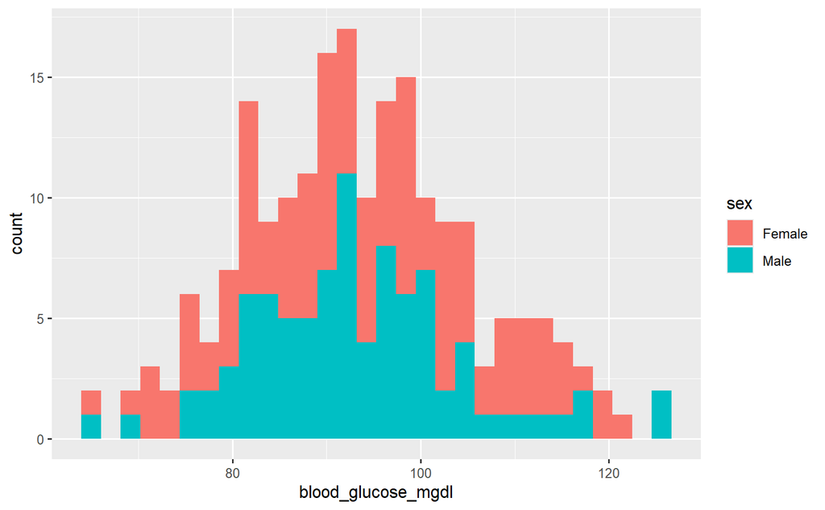

```r
ggplot(health,
       aes(
         x = blood_glucose_mgdl,
         fill = sex
       )) + geom_histogram()
```

**5.2 Scatter plot — height vs. weight**

Create a scatter plot of `height_cm` (x-axis) vs. `weight_kg` (y-axis), coloring points by `sex`. Add a linear regression line for each sex using `geom_smooth(method = "lm")`.

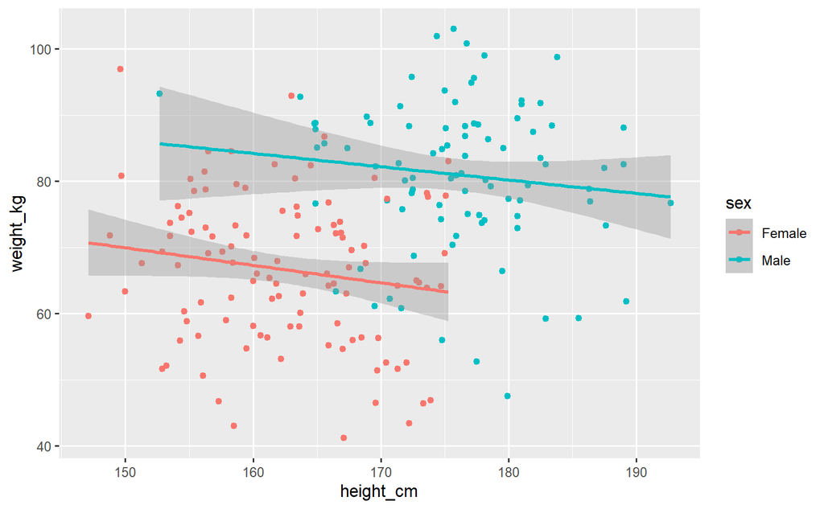

```r
ggplot(health,
       aes(
         x = height_cm,
         y= weight_kg,
         color = sex
       )) + geom_point() + geom_smooth(method = "lm")
```

**5.3 Box plot — BMI by sex**

Make a box plot of `bmi` for each `sex`. Overlay the individual data points using `geom_jitter()` with `width = 0.2` and `alpha = 0.4`.

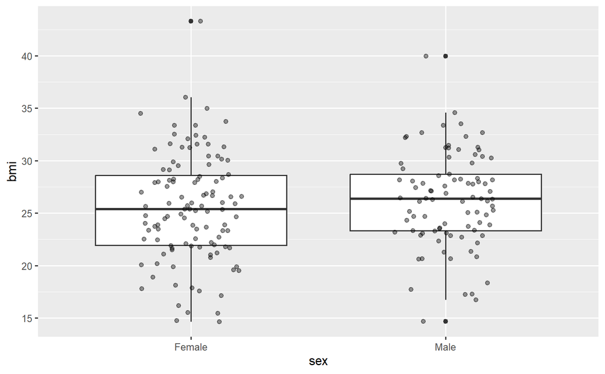

```r
ggplot(health,
       aes(
         x = sex,
         y = bmi
       )) + geom_boxplot() + geom_jitter(width=0.2,alpha=0.4)
```

**5.4 Bar chart — sample counts by hair color and sex**

Using `geom_bar()`, create a bar chart showing the number of samples for each `hair_color`, filled by `sex`. Use `position = "dodge"` so the bars for each sex are side by side.

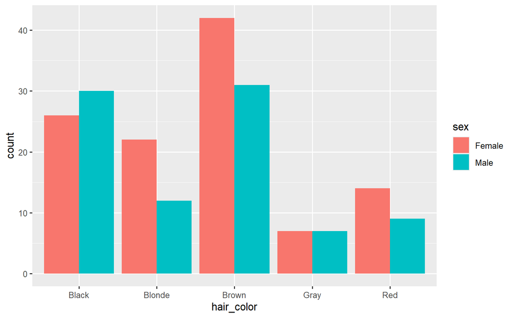

```r
ggplot(health,
       aes(
         x = hair_color,
         fill = sex,
       )) + geom_bar(position = "dodge")
```

**5.5 Scatter plot — BMI vs. LDL**

Plot `bmi` (x) vs. `LDL_mgdl` (y), coloring points by `glucose_category`. Choose a colorblind-friendly palette with `scale_color_brewer(palette = "Set2")`. Does there appear to be a relationship?

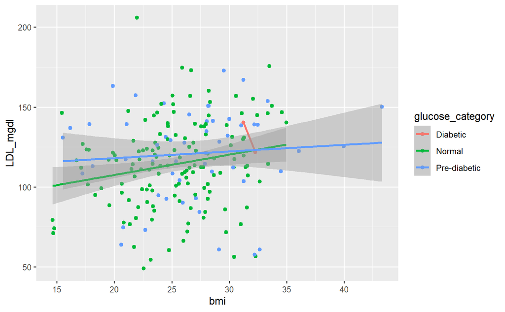

```r
ggplot(health,
       aes(
         x = bmi,
         y= LDL_mgdl,
         scale_color_brewer(palette = "Set2"),
         color = glucose_category
       )) + geom_point() +geom_smooth(method = "lm")
```

**5.6 Faceted plot — glucose vs. LDL by sex**

Plot `blood_glucose_mgdl` (x) vs. `LDL_mgdl` (y) as a scatter plot, then use `facet_wrap(~ sex)` to create separate panels for Males and Females.

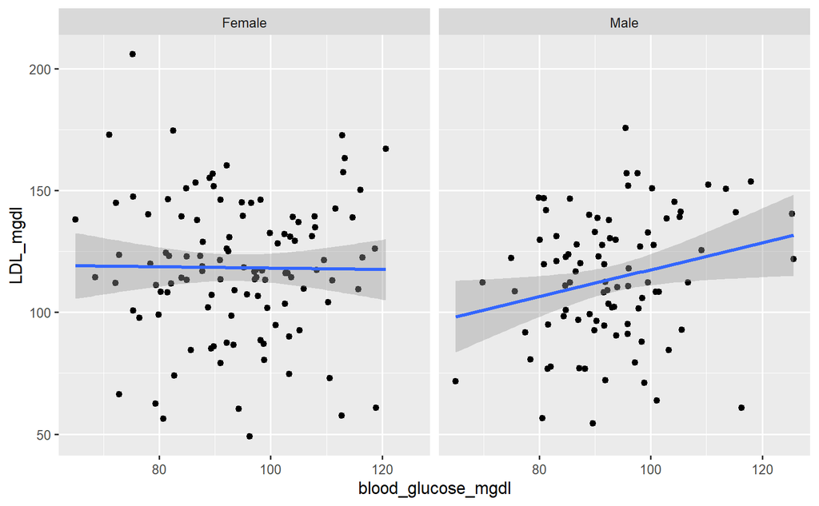

```r
ggplot(health,
       aes(
         x = blood_glucose_mgdl,
         y= LDL_mgdl,
       )) + geom_point() + geom_smooth(method = "lm") + facet_wrap(~sex)
```

```r
NA
NA
```

## Part 6 — Putting it together (open-ended)

**6.1** Using any combination of `dplyr` and `ggplot2`, create one additional plot of your choice that reveals something interesting about this dataset. Write 2–3 sentences below your plot describing what you observe.

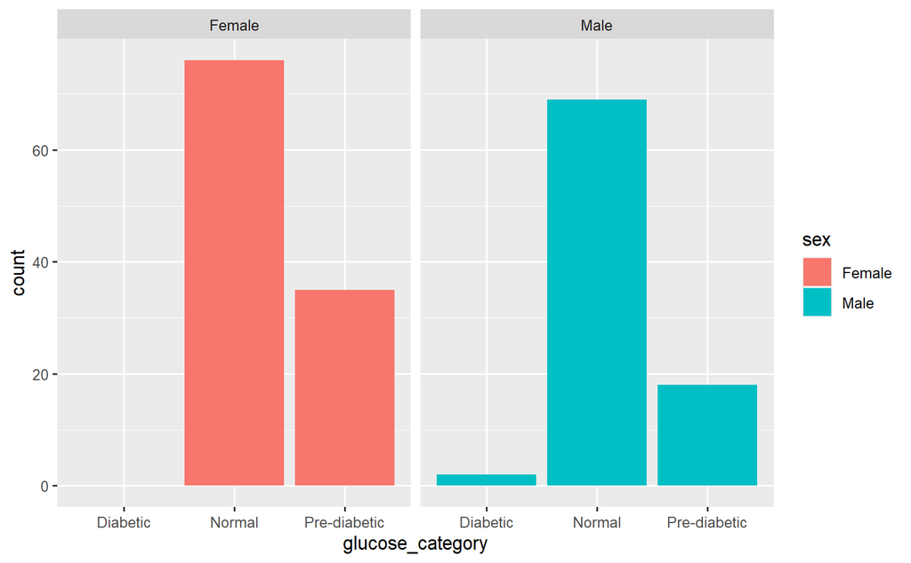

```r
ggplot(health,
       aes(
         x = glucose_category,
         fill=sex
       )) + geom_bar()+facet_wrap(~sex)
```

## Submission

Knit this document to HTML and submit the `.html` file.